## I selected the nkill.bCountryYr dataset from [http://vincentarelbundock.github.io/Rdatasets/]

## this source database is summarized as follows:

> Global Terrorism Database yearly summaries Description The Global Terrorism Database (GTD) “is a database of incidents of terrorism from 1970 onward”. Through 2015, this database contains information on 141,966 incidents.

## The csv I used includes:

> year integer year, 1970:2014. methodology an ordered factor giving the methodology / organization responsible for the data collection for most of the given year. The Pinkerton Global Intelligence Service (PGIS) managed data collection from 1970-01-01 to 1997-12-31. The Center for Terrorism and Intelligence Studies (CETIS) managed the project from 1998-01-01 to 2008-03-31. The Institute for the Study of Violent Groups (ISVG) carried the project from 2008-04-01 to 2011-10-31. The National Consortium for the Study of Terrorism and Responses to Terrorism (START) has managed data collection since 2011-11-01. For this variable, partial years are ignored, so methodology = CEDIS for 1998:2007, ISVG for 2008:2011, and START for 2012:2014. nkill number of confirmed fatalities for incidents in the given year, including attackers = sum(nkill, na.rm=TRUE) in the GTD incident data. NOTE: nkill in the GTD incident data includes both perpetrators and victims when both are available. It includes one when only one is available and is NA when neither is available. However, in most cases, we might expect that the more spectacular and lethal incidents would likely be more accurately reported. To the exent that this is true, it means that when numbers are missing, they are usually zero or small. This further suggests that the summary numbers recorded here probably represent a slight but not substantive undercount.

```
## [1] "H:/CLASS/MSDS_Bridge"
```

### Below is the Summary for the full dataset

```
##       X                 X1970             X1971              X1972
##  Length:206         Min.   : 0.0000   Min.   :  0.0000   Min.   :  0.000
##  Class :character   1st Qu.: 0.0000   1st Qu.:  0.0000   1st Qu.:  0.000
##  Mode  :character   Median : 0.0000   Median :  0.0000   Median :  0.000
##                     Mean   : 0.8301   Mean   :  0.8398   Mean   :  2.748
##                     3rd Qu.: 0.0000   3rd Qu.:  0.0000   3rd Qu.:  0.000
##                     Max.   :47.0000   Max.   :110.0000   Max.   :368.000
##      X1973             X1974             X1975             X1976
##  Min.   :  0.000   Min.   :  0.000   Min.   :  0.000   Min.   :  0.000
##  1st Qu.:  0.000   1st Qu.:  0.000   1st Qu.:  0.000   1st Qu.:  0.000
##  Median :  0.000   Median :  0.000   Median :  0.000   Median :  0.000
##  Mean   :  1.796   Mean   :  2.631   Mean   :  2.995   Mean   :  3.262
##  3rd Qu.:  0.000   3rd Qu.:  0.000   3rd Qu.:  0.000   3rd Qu.:  0.000
##  Max.   :210.000   Max.   :235.000   Max.   :245.000   Max.   :264.000
##      X1977             X1978             X1979            X1980
##  Min.   :  0.000   Min.   :  0.000   Min.   :  0.00   Min.   :   0.0
##  1st Qu.:  0.000   1st Qu.:  0.000   1st Qu.:  0.00   1st Qu.:   0.0
##  Median :  0.000   Median :  0.000   Median :  0.00   Median :   0.0
##  Mean   :  2.214   Mean   :  7.082   Mean   : 10.19   Mean   :  21.5
##  3rd Qu.:  0.000   3rd Qu.:  0.000   3rd Qu.:  1.00   3rd Qu.:   1.0
##  Max.   :103.000   Max.   :447.000   Max.   :286.00   Max.   :2383.0
##      X1981             X1982             X1983             X1984
##  Min.   :   0.00   Min.   :   0.00   Min.   :   0.00   Min.   :   0.00
##  1st Qu.:   0.00   1st Qu.:   0.00   1st Qu.:   0.00   1st Qu.:   0.00
##  Median :   0.00   Median :   0.00   Median :   0.00   Median :   0.00
##  Mean   :  23.55   Mean   :  24.93   Mean   :  45.84   Mean   :  50.72
##  3rd Qu.:   1.00   3rd Qu.:   0.00   3rd Qu.:   0.00   3rd Qu.:   1.00
##  Max.   :1578.00   Max.   :1562.00   Max.   :3277.00   Max.   :3617.00
##      X1985             X1986            X1987             X1988
##  Min.   :   0.00   Min.   :  0.00   Min.   :   0.00   Min.   :   0.00
##  1st Qu.:   0.00   1st Qu.:  0.00   1st Qu.:   0.00   1st Qu.:   0.00
##  Median :   0.00   Median :  0.00   Median :   0.00   Median :   0.00
##  Mean   :  34.44   Mean   : 24.29   Mean   :  31.45   Mean   :  34.91
##  3rd Qu.:   0.00   3rd Qu.:  1.00   3rd Qu.:   0.00   3rd Qu.:   1.00
##  Max.   :1575.00   Max.   :771.00   Max.   :1274.00   Max.   :1096.00
##      X1989             X1990            X1991             X1992
##  Min.   :   0.00   Min.   :   0.0   Min.   :   0.00   Min.   :   0.00
##  1st Qu.:   0.00   1st Qu.:   0.0   1st Qu.:   0.00   1st Qu.:   0.00
##  Median :   0.00   Median :   0.0   Median :   0.00   Median :   0.50
##  Mean   :  39.42   Mean   :  34.7   Mean   :  40.92   Mean   :  47.31
```

[output cut: 29 more lines]

```
##  Max.   :4612.00   Max.   :6648.00   Max.   :2863.00   Max.   :2583
##      X2010             X2011            X2012             X2013
##  Min.   :   0.00   Min.   :   0.0   Min.   :   0.00   Min.   :   0.0
##  1st Qu.:   0.00   1st Qu.:   0.0   1st Qu.:   0.00   1st Qu.:   0.0
##  Median :   0.00   Median :   0.0   Median :   0.00   Median :   0.0
##  Mean   :  37.48   Mean   :  39.8   Mean   :  74.91   Mean   : 107.9
##  3rd Qu.:   0.00   3rd Qu.:   0.0   3rd Qu.:   1.00   3rd Qu.:   2.0
##  Max.   :2071.00   Max.   :1865.0   Max.   :3521.00   Max.   :7038.0
##      X2014             X2015
##  Min.   :    0.0   Min.   :   0.00
##  1st Qu.:    0.0   1st Qu.:   0.00
##  Median :    0.0   Median :   0.00
##  Mean   :  211.4   Mean   : 186.51
##  3rd Qu.:    4.0   3rd Qu.:   4.75
##  Max.   :13076.0   Max.   :8831.00
```

## Below is the mean and median for the full dataset for 2010 and 2015

I selected these years as I saw from the summary greatest means were seen in 2013 through 2015 and I wanted to compare a 5 year span so I selected 2010 and 2015. Probably with a better knowledge of the topic I could have made different inferences about this dataset.

```
## [1] "The mean for 2010 was 37.4757281553398"
```

```
## [1] "The median for 2010 was 0"
```

```
## [1] "The mean for 2015 was 186.514563106796"
```

```
## [1] "The median for 2010 was 0"
```

## Below I subsetted the full dataset for just 2010 and 2015 in order to compare them using a boxplot. In order to run a box plot I needed to restructure the data. you can see from the two sample below how it was originally structured and then how it is structure after using the melt function from the reshape2 library I also changed the column headings to Country, Year, Killings

```
##                Country X2010 X2015
## 1          Afghanistan  1058  6208
## 2              Albania     0     0
## 3              Algeria   109    21
## 4              Andorra     0     0
## 5               Angola     4     0
## 6  Antigua and Barbuda     0     0
## 7            Argentina     0     0
## 8              Armenia     0     0
## 9            Australia     0     2
## 10             Austria     0     0
```

```
##                Country Year Killings
## 1          Afghanistan 2010     1058
## 2              Albania 2010        0
## 3              Algeria 2010      109
## 4              Andorra 2010        0
## 5               Angola 2010        4
## 6  Antigua and Barbuda 2010        0
## 7            Argentina 2010        0
## 8              Armenia 2010        0
## 9            Australia 2010        0
## 10             Austria 2010        0
```

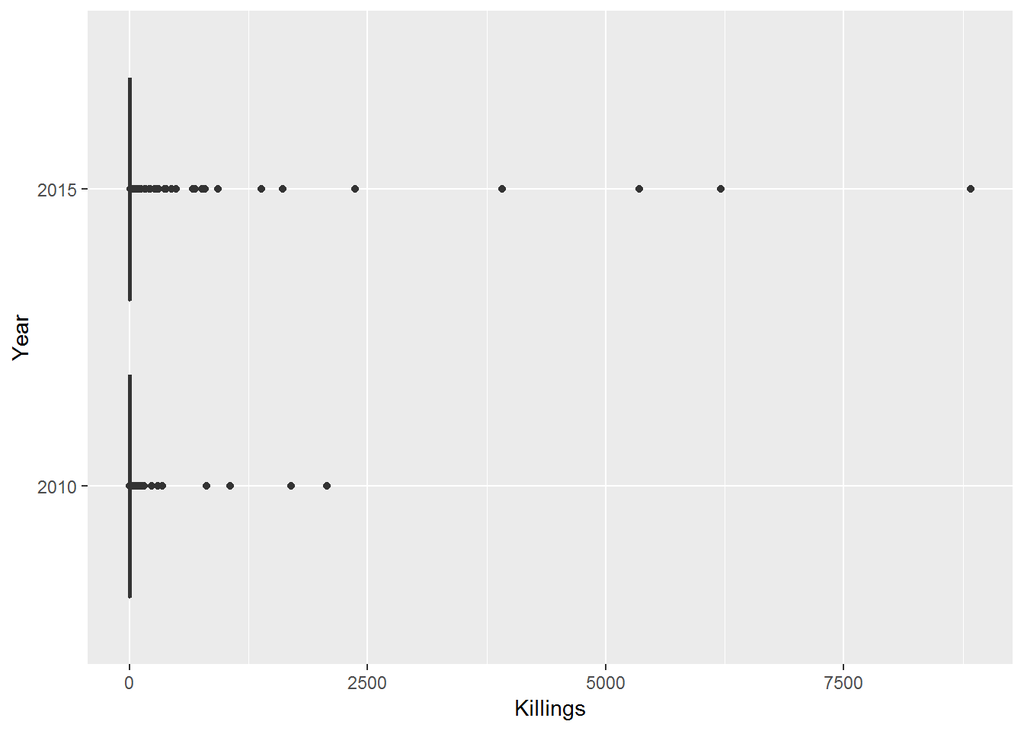

##Then I sorted the original dataset in descending order based on 2015 and selected the top 10 rows

```
##         Country X1970 X1971 X1972 X1973 X1974 X1975 X1976 X1977 X1978
## 86         Iraq     0     0     0     0     0     0    12     0     0
## 1   Afghanistan     0     0     0     0     0     0     0     0     0
## 132     Nigeria     0     0     0     0     0     0     0     0     0
## 177       Syria     0     0     0     0     1     0     5     1     0
## 202       Yemen     0     0     0     0     0     0     0     0     0
## 136    Pakistan     1     0     0     0     0     1     1     0     5
## 161     Somalia     0     0     0     0     0     0     0     0     0
## 30     Cameroon     0     0     0     0     0     0     0     0     0
## 52        Egypt     0     1     0     0     0     0     0     1     2
## 188     Ukraine     0     0     0     0     0     0     0     0     0
##     X1979 X1980 X1981 X1982 X1983 X1984 X1985 X1986 X1987 X1988 X1989
## 86      1     8     0    96     1     0     0     0     0    43     0
## 1      53     0     0     0     0     0     0     0     0   128    10
## 132     0     0     0     0     1     0     0     0     0     4     0
```

[output cut: 40 more lines]

## Next I subsetted the original dataset for all the countries that were listed when sorted in descending order on the year 2015, and selected only those countries for 2010 and 2015 and printed summary, the mean, and the median for each year of the subset

```
##  [1] "Iraq"        "Afghanistan" "Nigeria"     "Syria"       "Yemen"
##  [6] "Pakistan"    "Somalia"     "Cameroon"    "Egypt"       "Ukraine"
```

```
##    Country              X2010            X2015
##  Length:10          Min.   :   0.0   Min.   : 765
##  Class :character   1st Qu.:   2.0   1st Qu.:1043
##  Mode  :character   Median : 206.0   Median :1990
##                     Mean   : 558.7   Mean   :3216
##                     3rd Qu.: 879.8   3rd Qu.:4992
##                     Max.   :2071.0   Max.   :8831
```

```
## [1] "The subset mean for 2010 was 558.7"
```

```
## [1] "The subset median for 2010 was 206"
```

```
## [1] "The subset mean for 2015 was 3215.7"
```

```
## [1] "The subset median for 2015 was 1989.5"
```

### Then I compared the mean for each between the full and subsetted dataset

```
## [1] "comparing means"
```

```
## [1] "subset_mean_2010  is larger than  mean_2010"
```

```
## [1] "subset_mean_2015  is larger than  mean_2015"
```

```
## [1] "comparing medians"
```

```
## [1] "subset_median_2010  is larger than  median_2010"
```

```
## [1] "subset_median_2015  is larger than  median_2015"
```

### Next I switched out the value for Afghanistan to be AF and Cameroon to be CR

```r
"Afghanistan" %in% dfsub$Country
```

```
## [1] TRUE
```

```r
dfsub$Country[dfsub$Country=='Afghanistan']<-'AF'
"Afghanistan" %in% dfsub$Country
```

```
## [1] FALSE
```

```r
dfsub$Country[dfsub$Country=='Cameroon']<-'CR'
head(dfsub, n=10)
```

```
##      Country X2010 X2015
## 1         AF  1058  6208
## 30        CR     5   928
## 52     Egypt     0   790
## 86      Iraq  2071  8831
## 132  Nigeria   117  5351
## 136 Pakistan  1695  1606
## 161  Somalia   295  1389
## 177    Syria     0  3916
## 188  Ukraine     1   765
## 202    Yemen   345  2373
```

### Then I created a box plot for the subset

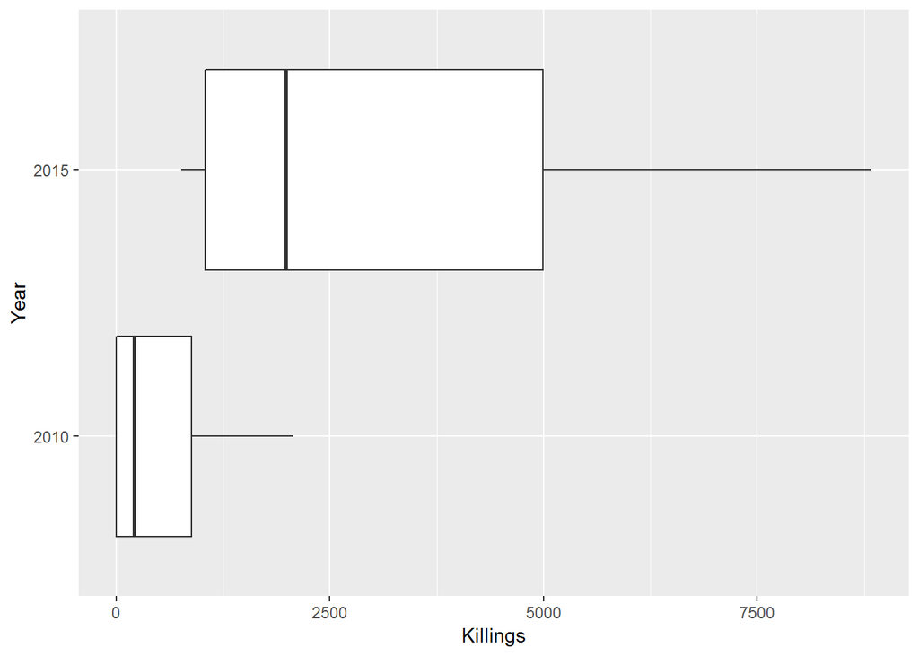